# Introduction

We will use the Yale Faces Dataset, it contains 165 gif images of 11 subjects, each with one parameter: The link to the dataset is as shown: http://vision.ucsd.edu/content/yale-face-database

To build the RCNN we will use the Matterport Mask R-CNN project provides a library that allows you to develop and train Mask R-CNN Keras models for your own object detection tasks.

The link to the Matterport Mask R-CNN project is as shown below:

https://github.com/matterport/Mask_RCNN

The Link to the Emotion Identification project is as shown below:

https://github.com/Shabarish033/GFP

# Creation of the Model

```python
import sys
import itertools
import math
import logging
import json
import re
import random
from collections import OrderedDict
import matplotlib
import matplotlib.pyplot as plt
import matplotlib.patches as patches
import matplotlib.lines as lines
from matplotlib.patches import Polygon

# Import Mask RCNN #We will be using the Matterport Mask RCNN library
from mrcnn import utils
from mrcnn import visualize
from mrcnn.visualize import display_images
import mrcnn.model as modellib
from mrcnn.model import log

%matplotlib inline
```

```python
#Now we have the images in the 'images' folder and xml files in the 'annots' folder
#The code below, creates a class for applying the masks, defining the object class to be identified and splitting the dataset into training and test set
import os
from xml.etree import ElementTree as ET
import numpy as np
from mrcnn.utils import Dataset

# class that defines and loads the building dataset
class BuildingDataset(Dataset):
    # load the dataset definitions
    def load_dataset(self, dataset_dir, is_train=True):
        # define one class
        self.add_class("dataset", 1, "Glasses") #add_class is defined in mrcnn.utils, it is used to define the class
        self.add_class("dataset", 2, "Sleepy")
        self.add_class("dataset", 3, "Surprised")
        self.add_class("dataset", 4, "Normal")
        self.add_class("dataset", 5, "Sad")
        self.add_class("dataset", 6, "Happy")
        self.add_class("dataset", 7, "Noglasses")
        self.add_class("dataset", 8, "Wink")
        # define data locations
        image_path = os.path.join(dataset_dir, 'images')
        annotations_path = os.path.join(dataset_dir, 'annots')
        # find all images
        for filename in os.listdir(image_path):
            # extract image id
            image_id = filename[:-4] #returns the path to the image file name excluding '.jpg', [-4]
            # We skip the images shown below, since the have some errors
            if image_id in ['00028']:
                continue
            if image_id in ['00029']:
                continue
            if image_id in ['00031']:
                continue
            if image_id in ['00032']:
                continue
            if image_id in ['00033']:
                continue
            if image_id in ['00034']:
                continue
            if image_id in ['00035']:
                continue
            if image_id in ['00036']:
                continue
            if image_id in ['00037']:
                continue
            if image_id in ['00038']:
                continue
            if image_id in ['00039']:
                continue
            if image_id in ['00040']:
                continue
            if image_id in ['00041']:
                continue
            if image_id in ['00042']:
                continue
            if image_id in ['00043']:
                continue
            if image_id in ['00044']:
                continue
            if image_id in ['00045']:
                continue
            if image_id in ['00086']:
                continue

            if is_train and int(image_id) >= 91: #80% of images go to train
                continue
            # skip all images before 90 if we are building the test/val set
            if not is_train and int(image_id) < 91: #20% of images go to test
                continue
            img_path = os.path.join(image_path, filename)
            ann_path = os.path.join(annotations_path, str(image_id + '.xml'))
            # add to dataset
            self.add_image('dataset', image_id=image_id, path=img_path, annotation=ann_path, class_ids=[0,1,2,3,4,5,6,7,8])

    # extract bounding boxes from an annotation file
    def extract_boxes(self, filename):
        # load and parse the file
        tree = ET.parse(filename)
        # get the root of the document
        root = tree.getroot()
        # extract each bounding box
        boxes = list()
        for box in root.findall('.//bndbox'):
            xmin = int(box.find('xmin').text)
            ymin = int(box.find('ymin').text)
            xmax = int(box.find('xmax').text)
            ymax = int(box.find('ymax').text)
            ClassName = str(box.find('ClassName').text)
            coors = [xmin, ymin, xmax, ymax, ClassName]
            boxes.append(coors)
            # extract image dimensions
        width = 320
        height = 243
        return boxes, width, height

    # load the masks for an image
    def load_mask(self, image_id): #Returns a matrix containing the dimensions of the mask size = [Len, Width, number_Classes]
        # get details of image
        info = self.image_info[image_id]
        # define box file location
        path = info['annotation']
        # load XML
        boxes, w, h = self.extract_boxes(path)
        # create one array for all masks, each on a different channel
        masks = np.zeros([h, w, len(boxes)], dtype='uint8')
        # create masks
        class_ids = list()
        for i in range(len(boxes)):
            box = boxes[i]
            row_s, row_e = box[1], box[3]
            col_s, col_e = box[0], box[2]
            if (box[4] == 'Glasses'):
                masks[row_s:row_e, col_s:col_e, i] = 1
                class_ids.append(self.class_names.index('Glasses'))
            elif (box[4] == 'Sleepy'):
                masks[row_s:row_e, col_s:col_e, i] = 2
                class_ids.append(self.class_names.index('Sleepy'))
            elif (box[4] == 'Surprised'):
                masks[row_s:row_e, col_s:col_e, i] = 3
                class_ids.append(self.class_names.index('Surprised'))
            elif (box[4] == 'Normal'):
                masks[row_s:row_e, col_s:col_e, i] = 4
                class_ids.append(self.class_names.index('Normal'))
            elif (box[4] == 'Sad'):
                masks[row_s:row_e, col_s:col_e, i] = 5
                class_ids.append(self.class_names.index('Sad'))
            elif (box[4] == 'Happy'):
                masks[row_s:row_e, col_s:col_e, i] = 6
                class_ids.append(self.class_names.index('Happy'))
            elif (box[4] == 'Noglasses'):
                masks[row_s:row_e, col_s:col_e, i] = 7
                class_ids.append(self.class_names.index('Noglasses'))
            elif (box[4] == 'Wink'):
                masks[row_s:row_e, col_s:col_e, i] = 8
                class_ids.append(self.class_names.index('Wink'))
            else:
                pass
        return masks, np.asarray(class_ids, dtype='int32')

    # load an image reference
    def image_reference(self, image_id): #returns path to image
        info = self.image_info[image_id]
        return info['path']
```

```python
#Splitting Train Set and Test Set
# train set
train_set = BuildingDataset()
train_set.load_dataset('Emotions', is_train=True)
train_set.prepare()
print('Train: %d' % len(train_set.image_ids))

# test/val set
test_set = BuildingDataset()
test_set.load_dataset('Emotions', is_train=False)
test_set.prepare()
print('Test: %d' % len(test_set.image_ids))
```

```
Train: 72
Test: 30
```

```python
print("Image Count: {}".format(len(train_set.image_ids)))
print("Class Count: {}".format(train_set.num_classes))
for i, info in enumerate(train_set.class_info):
    print("{:3}. {:50}".format(i, info['name']))
```

```
Image Count: 72
Class Count: 9
  0. BG
  1. Glasses
  2. Sleepy
  3. Surprised
  4. Normal
  5. Sad
  6. Happy
  7. Noglasses
  8. Wink
```

# Exploratory Analysis

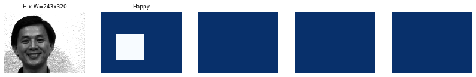

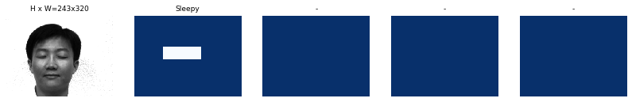

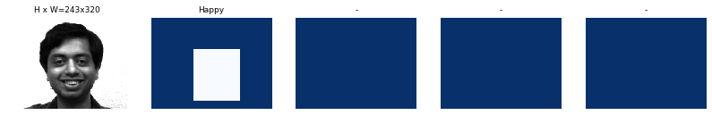

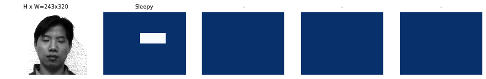

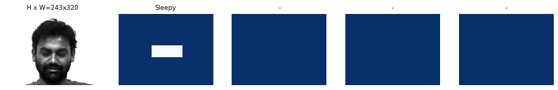

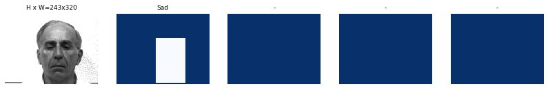

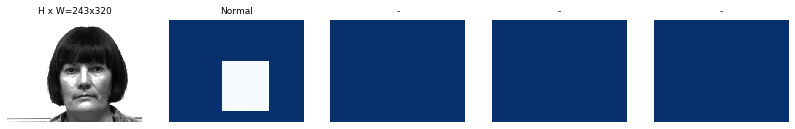

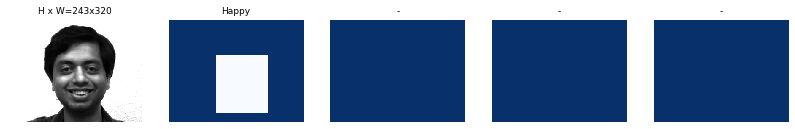

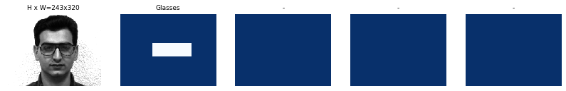

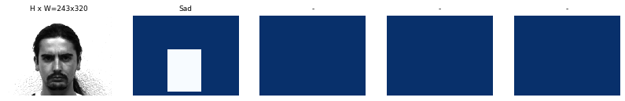

```python
#Display Samples along with the masks
image_ids = np.random.choice(train_set.image_ids, 10)
for image_id in image_ids:
    image = train_set.load_image(image_id)
    mask, class_ids = train_set.load_mask(image_id)
    visualize.display_top_masks(image, mask, class_ids, train_set.class_names)
```

Bounding Boxes

```
image_id  24 Emotions\images\00025.png
image                    shape: (243, 320, 3)         min:    0.00000  max:  255.00000  uint8
mask                     shape: (243, 320, 1)         min:    0.00000  max:    6.00000  uint8
class_ids                shape: (1,)                  min:    6.00000  max:    6.00000  int32
bbox                     shape: (1, 4)                min:   86.00000  max:  234.00000  int32
```

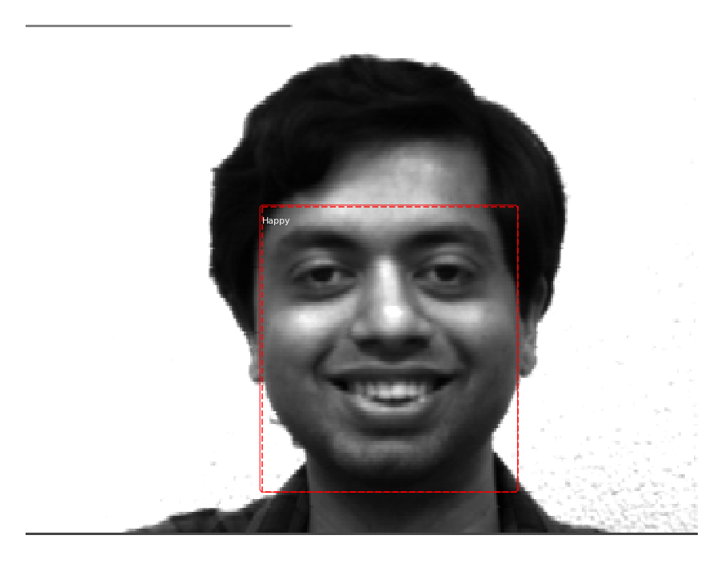

```python
# Load random image and mask.
image_id = random.choice(train_set.image_ids)
image = train_set.load_image(image_id)
mask, class_ids = train_set.load_mask(image_id)
# Compute Bounding box
bbox = utils.extract_bboxes(mask)

# Display image and additional stats
print("image_id ", image_id, train_set.image_reference(image_id))
log("image", image)
log("mask", mask)
log("class_ids", class_ids)
log("bbox", bbox)
# Display image and instances
visualize.display_instances(image, bbox, mask, class_ids, train_set.class_names)
```

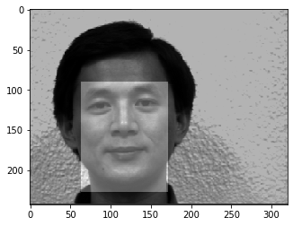

```python
#We will now test if the mask is applied to the image correctly
#Load the image
image_id = random.choice(train_set.image_ids)
image = train_set.load_image(image_id)
#print(image.shape)
#Load the Mask
mask, class_id = train_set.load_mask(image_id)
#print(mask.shape)
# plot image
plt.imshow(image)
# plot mask
plt.imshow(mask[:, :, 0], cmap='gray', alpha=0.3)
plt.show()
#print(class_id)
```

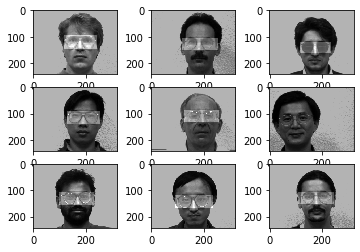

```python
# plot first few images
for i in range(9): #We will be plotting 3 images
    # define subplot
    plt.subplot(330 + 1 + i)
    # plot raw pixel dat
    image = train_set.load_image(i)
    plt.imshow(image) #First display images
    # plot all masks
    mask, _ = train_set.load_mask(i) #Get the size of the masks
    for j in range(mask.shape[2]): #mask.shape[2], identifies the total identified objects in an image
        plt.imshow(mask[:, :, j], cmap='gray', alpha=0.3)
# show the figure
plt.show()
```

```python
#Display info about all the images in the training set
for image_id in train_set.image_ids: #Iterate for all the images in the training set
    # load image info
    info = train_set.image_info[image_id]
    # display on the console
    print(info) #Gives info of the image ID, the data Source, image path, annotation file path
```

```
{'id': '00001', 'source': 'dataset', 'path': 'Emotions\\images\\00001.png', 'annotation': 'Emotions\\annots\\00001.xml', 'class_ids': [0, 1, 2, 3, 4, 5, 6, 7, 8]}
{'id': '00002', 'source': 'dataset', 'path': 'Emotions\\images\\00002.png', 'annotation': 'Emotions\\annots\\00002.xml', 'class_ids': [0, 1, 2, 3, 4, 5, 6, 7, 8]}
{'id': '00003', 'source': 'dataset', 'path': 'Emotions\\images\\00003.png', 'annotation': 'Emotions\\annots\\00003.xml', 'class_ids': [0, 1, 2, 3, 4, 5, 6, 7, 8]}
{'id': '00004', 'source': 'dataset', 'path': 'Emotions\\images\\00004.png', 'annotation': 'Emotions\\annots\\00004.xml', 'class_ids': [0, 1, 2, 3, 4, 5, 6, 7, 8]}
{'id': '00005', 'source': 'dataset', 'path': 'Emotions\\images\\00005.png', 'annotation': 'Emotions\\annots\\00005.xml', 'class_ids': [0, 1, 2, 3, 4, 5, 6, 7, 8]}
{'id': '00006', 'source': 'dataset', 'path': 'Emotions\\images\\00006.png', 'annotation': 'Emotions\\annots\\00006.xml', 'class_ids': [0, 1, 2, 3, 4, 5, 6, 7, 8]}
{'id': '00007', 'source': 'dataset', 'path': 'Emotions\\images\\00007.png', 'annotation': 'Emotions\\annots\\00007.xml', 'class_ids': [0, 1, 2, 3, 4, 5, 6, 7, 8]}
{'id': '00008', 'source': 'dataset', 'path': 'Emotions\\images\\00008.png', 'annotation': 'Emotions\\annots\\00008.xml', 'class_ids': [0, 1, 2, 3, 4, 5, 6, 7, 8]}
{'id': '00009', 'source': 'dataset', 'path': 'Emotions\\images\\00009.png', 'annotation': 'Emotions\\annots\\00009.xml', 'class_ids': [0, 1, 2, 3, 4, 5, 6, 7, 8]}
{'id': '00010', 'source': 'dataset', 'path': 'Emotions\\images\\00010.png', 'annotation': 'Emotions\\annots\\00010.xml', 'class_ids': [0, 1, 2, 3, 4, 5, 6, 7, 8]}
{'id': '00011', 'source': 'dataset', 'path': 'Emotions\\images\\00011.png', 'annotation': 'Emotions\\annots\\00011.xml', 'class_ids': [0, 1, 2, 3, 4, 5, 6, 7, 8]}
{'id': '00012', 'source': 'dataset', 'path': 'Emotions\\images\\00012.png', 'annotation': 'Emotions\\annots\\00012.xml', 'class_ids': [0, 1, 2, 3, 4, 5, 6, 7, 8]}
{'id': '00013', 'source': 'dataset', 'path': 'Emotions\\images\\00013.png', 'annotation': 'Emotions\\annots\\00013.xml', 'class_ids': [0, 1, 2, 3, 4, 5, 6, 7, 8]}
{'id': '00014', 'source': 'dataset', 'path': 'Emotions\\images\\00014.png', 'annotation': 'Emotions\\annots\\00014.xml', 'class_ids': [0, 1, 2, 3, 4, 5, 6, 7, 8]}
{'id': '00015', 'source': 'dataset', 'path': 'Emotions\\images\\00015.png', 'annotation': 'Emotions\\annots\\00015.xml', 'class_ids': [0, 1, 2, 3, 4, 5, 6, 7, 8]}
{'id': '00016', 'source': 'dataset', 'path': 'Emotions\\images\\00016.png', 'annotation': 'Emotions\\annots\\00016.xml', 'class_ids': [0, 1, 2, 3, 4, 5, 6, 7, 8]}
{'id': '00017', 'source': 'dataset', 'path': 'Emotions\\images\\00017.png', 'annotation': 'Emotions\\annots\\00017.xml', 'class_ids': [0, 1, 2, 3, 4, 5, 6, 7, 8]}
{'id': '00018', 'source': 'dataset', 'path': 'Emotions\\images\\00018.png', 'annotation': 'Emotions\\annots\\00018.xml', 'class_ids': [0, 1, 2, 3, 4, 5, 6, 7, 8]}
{'id': '00019', 'source': 'dataset', 'path': 'Emotions\\images\\00019.png', 'annotation': 'Emotions\\annots\\00019.xml', 'class_ids': [0, 1, 2, 3, 4, 5, 6, 7, 8]}
{'id': '00020', 'source': 'dataset', 'path': 'Emotions\\images\\00020.png', 'annotation': 'Emotions\\annots\\00020.xml', 'class_ids': [0, 1, 2, 3, 4, 5, 6, 7, 8]}
{'id': '00021', 'source': 'dataset', 'path': 'Emotions\\images\\00021.png', 'annotation': 'Emotions\\annots\\00021.xml', 'class_ids': [0, 1, 2, 3, 4, 5, 6, 7, 8]}
{'id': '00022', 'source': 'dataset', 'path': 'Emotions\\images\\00022.png', 'annotation': 'Emotions\\annots\\00022.xml', 'class_ids': [0, 1, 2, 3, 4, 5, 6, 7, 8]}
{'id': '00023', 'source': 'dataset', 'path': 'Emotions\\images\\00023.png', 'annotation': 'Emotions\\annots\\00023.xml', 'class_ids': [0, 1, 2, 3, 4, 5, 6, 7, 8]}
{'id': '00024', 'source': 'dataset', 'path': 'Emotions\\images\\00024.png', 'annotation': 'Emotions\\annots\\00024.xml', 'class_ids': [0, 1, 2, 3, 4, 5, 6, 7, 8]}
{'id': '00025', 'source': 'dataset', 'path': 'Emotions\\images\\00025.png', 'annotation': 'Emotions\\annots\\00025.xml', 'class_ids': [0, 1, 2, 3, 4, 5, 6, 7, 8]}
{'id': '00026', 'source': 'dataset', 'path': 'Emotions\\images\\00026.png', 'annotation': 'Emotions\\annots\\00026.xml', 'class_ids': [0, 1, 2, 3, 4, 5, 6, 7, 8]}
```

[output cut: 46 more lines]

```
7
```

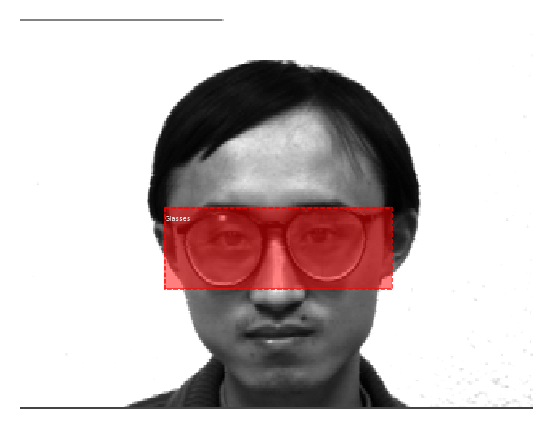

```python
# Load random image and mask.
image_id = random.choice(train_set.image_ids)
print(image_id)
image = train_set.load_image(image_id)
mask, class_ids = train_set.load_mask(image_id)
# Compute Bounding box
bbox = utils.extract_bboxes(mask)
visualize.display_instances(image, bbox, mask, class_ids, train_set.class_names)
```

```
21
```

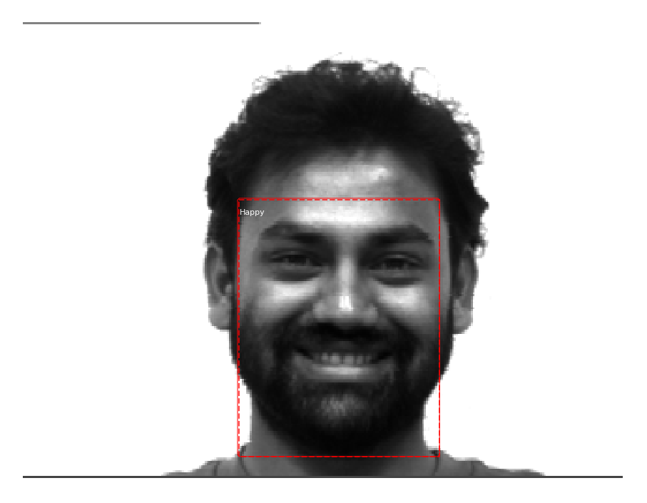

```python
#image_id = 5
# Load random image and mask.
image_id = random.choice(train_set.image_ids)
print(image_id)
image = train_set.load_image(image_id)
mask, class_ids = train_set.load_mask(image_id)
# Compute Bounding box
bbox = utils.extract_bboxes(mask)
visualize.display_instances(image, bbox, mask, class_ids, train_set.class_names)
```

# Training the Model

To train the model we will use Transfer Learning: Transfer learning is a research problem in machine learning that focuses on storing knowledge gained while solving one problem and applying it to a different but related problem. The Mask R-CNN model pre-fit on the MS COCO object detection dataset can be used as a starting point and then tailored to the specific dataset.

```python
#Create the Model
from mrcnn.config import Config
from mrcnn.model import MaskRCNN
# define a configuration for the model
class EmotionConfig(Config):
    # define the name of the configuration
    NAME = "Emotion_cfg"
    # number of classes (background + Emotion)
    NUM_CLASSES = 1 + 8
    # number of training steps per epoch
    STEPS_PER_EPOCH = 72
# prepare config
config = EmotionConfig()
config.display()
```

```
Configurations:
BACKBONE                       resnet101
BACKBONE_STRIDES               [4, 8, 16, 32, 64]
BATCH_SIZE                     2
BBOX_STD_DEV                   [0.1 0.1 0.2 0.2]
COMPUTE_BACKBONE_SHAPE         None
DETECTION_MAX_INSTANCES        100
DETECTION_MIN_CONFIDENCE       0.7
DETECTION_NMS_THRESHOLD        0.3
FPN_CLASSIF_FC_LAYERS_SIZE     1024
GPU_COUNT                      1
GRADIENT_CLIP_NORM             5.0
IMAGES_PER_GPU                 2
IMAGE_CHANNEL_COUNT            3
IMAGE_MAX_DIM                  1024
IMAGE_META_SIZE                21
IMAGE_MIN_DIM                  800
IMAGE_MIN_SCALE                0
IMAGE_RESIZE_MODE              square
IMAGE_SHAPE                    [1024 1024    3]
LEARNING_MOMENTUM              0.9
LEARNING_RATE                  0.001
LOSS_WEIGHTS                   {'rpn_class_loss': 1.0, 'rpn_bbox_loss': 1.0, 'mrcnn_class_loss': 1.0, 'mrcnn_bbox_loss': 1.0, 'mrcnn_mask_loss': 1.0}
MASK_POOL_SIZE                 14
MASK_SHAPE                     [28, 28]
MAX_GT_INSTANCES               100
MEAN_PIXEL                     [123.7 116.8 103.9]
MINI_MASK_SHAPE                (56, 56)
NAME                           Emotion_cfg
NUM_CLASSES                    9
POOL_SIZE                      7
POST_NMS_ROIS_INFERENCE        1000
POST_NMS_ROIS_TRAINING         2000
PRE_NMS_LIMIT                  6000
ROI_POSITIVE_RATIO             0.33
RPN_ANCHOR_RATIOS              [0.5, 1, 2]
RPN_ANCHOR_SCALES              (32, 64, 128, 256, 512)
RPN_ANCHOR_STRIDE              1
RPN_BBOX_STD_DEV               [0.1 0.1 0.2 0.2]
RPN_NMS_THRESHOLD              0.7
RPN_TRAIN_ANCHORS_PER_IMAGE    256
STEPS_PER_EPOCH                72
TOP_DOWN_PYRAMID_SIZE          256
TRAIN_BN                       False
TRAIN_ROIS_PER_IMAGE           200
USE_MINI_MASK                  True
USE_RPN_ROIS                   True
VALIDATION_STEPS               50
WEIGHT_DECAY                   0.0001
```

```
image_id  11 Emotions\images\00012.png
image                    shape: (243, 320, 3)         min:    0.00000  max:  255.00000  uint8
mask                     shape: (243, 320, 1)         min:    0.00000  max:    1.00000  uint8
class_ids                shape: (1,)                  min:    1.00000  max:    1.00000  int32
bbox                     shape: (1, 4)                min:  111.00000  max:  264.00000  int32
```

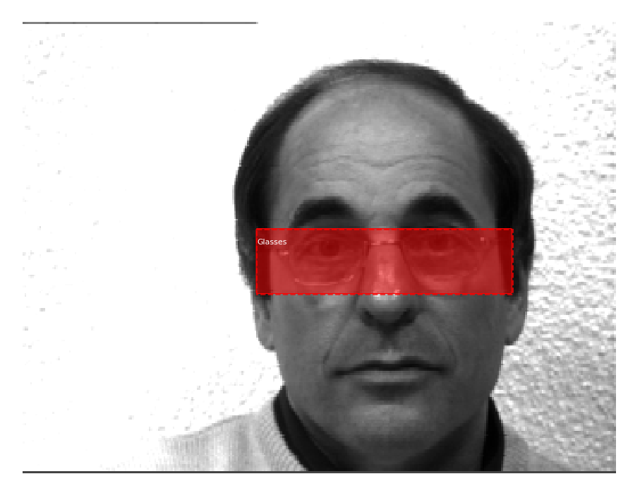

```python
# Load random image and mask.
image_id = random.choice(train_set.image_ids)
image = train_set.load_image(image_id)
mask, class_ids = train_set.load_mask(image_id)
# Compute Bounding box
bbox = utils.extract_bboxes(mask)

# Display image and additional stats
print("image_id ", image_id, train_set.image_reference(image_id))
log("image", image)
log("mask", mask)
log("class_ids", class_ids)
log("bbox", bbox)
# Display image and instances
visualize.display_instances(image, bbox, mask, class_ids, train_set.class_names)
```

```
image_id:  19 Emotions\images\00020.png
Original shape:  (243, 320, 3)
image                    shape: (1024, 1024, 3)       min:    0.00000  max:  255.00000  uint8
mask                     shape: (1024, 1024, 1)       min:    0.00000  max:    6.00000  uint8
class_ids                shape: (1,)                  min:    6.00000  max:    6.00000  int32
bbox                     shape: (1, 4)                min:  398.00000  max:  880.00000  int32
```

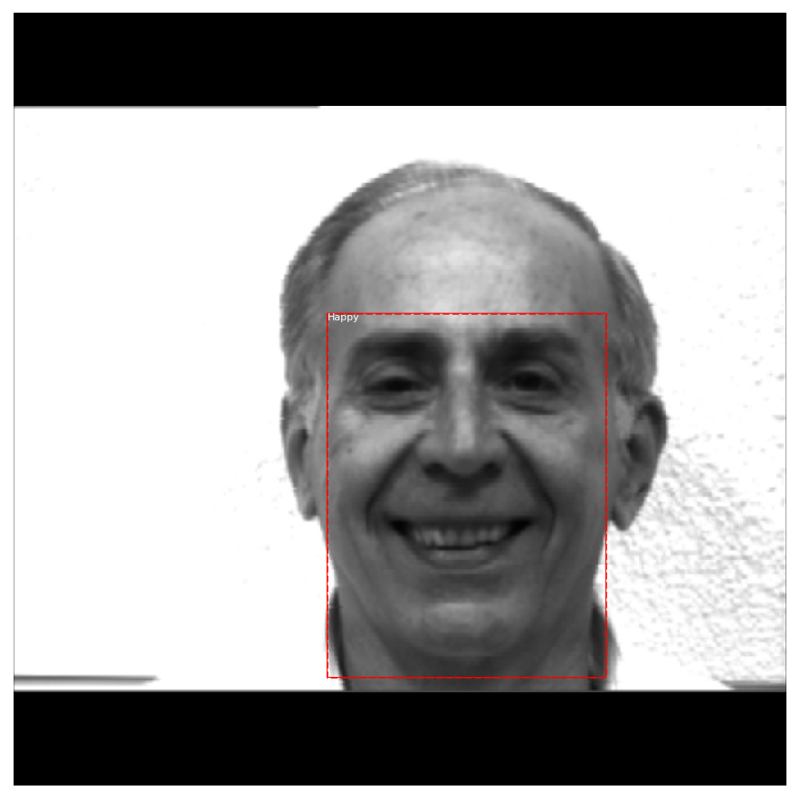

```python
# Load random image and mask.
image_id = np.random.choice(train_set.image_ids, 1)[0]
image = train_set.load_image(image_id)
mask, class_ids = train_set.load_mask(image_id)
original_shape = image.shape
# Resize
image, window, scale, padding, _ = utils.resize_image(
    image,
    min_dim=config.IMAGE_MIN_DIM,
    max_dim=config.IMAGE_MAX_DIM,
    mode=config.IMAGE_RESIZE_MODE)
mask = utils.resize_mask(mask, scale, padding)
# Compute Bounding box
bbox = utils.extract_bboxes(mask)

# Display image and additional stats
print("image_id: ", image_id, train_set.image_reference(image_id))
print("Original shape: ", original_shape)
log("image", image)
log("mask", mask)
log("class_ids", class_ids)
log("bbox", bbox)
# Display image and instances
visualize.display_instances(image, bbox, mask, class_ids, train_set.class_names)
```

```
image                    shape: (1024, 1024, 3)       min:    0.00000  max:  255.00000  uint8
image_meta               shape: (21,)                 min:    0.00000  max: 1024.00000  float64
class_ids                shape: (1,)                  min:    1.00000  max:    1.00000  int32
bbox                     shape: (1, 4)                min:  397.00000  max:  823.00000  int32
mask                     shape: (1024, 1024, 1)       min:    0.00000  max:    1.00000  uint8
```

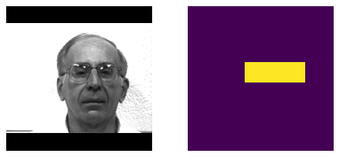

```python
image_id = np.random.choice(train_set.image_ids, 1)[0]
image, image_meta, class_ids, bbox, mask = modellib.load_image_gt(
    train_set, config, image_id, use_mini_mask=False)

log("image", image)
log("image_meta", image_meta)
log("class_ids", class_ids)
log("bbox", bbox)
log("mask", mask)

display_images([image]+[mask[:,:,i] for i in range(min(mask.shape[-1], 7))])
```

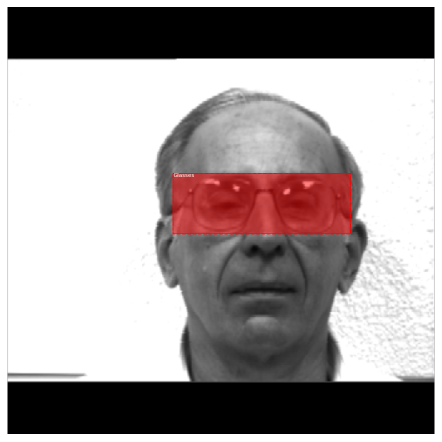

```python
visualize.display_instances(image, bbox, mask, class_ids, train_set.class_names)
```

```
WARNING:root:'augment' is deprecated. Use 'augmentation' instead.
```

```
mask                     shape: (56, 56, 1)           min:    1.00000  max:    1.00000  bool
```

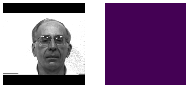

```python
# Add augmentation and mask resizing.
image, image_meta, class_ids, bbox, mask = modellib.load_image_gt(
    train_set, config, image_id, augment=True, use_mini_mask=True)
log("mask", mask)
display_images([image]+[mask[:,:,i] for i in range(min(mask.shape[-1], 7))])
```

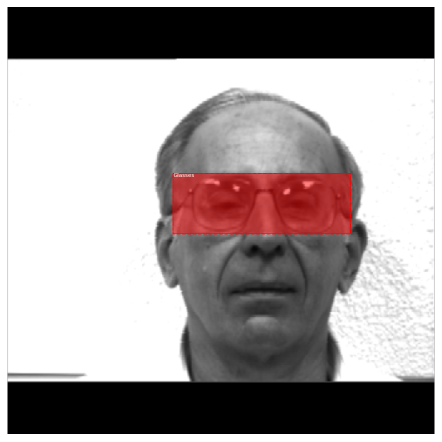

```python
mask = utils.expand_mask(bbox, mask, image.shape)
visualize.display_instances(image, bbox, mask, class_ids, train_set.class_names)
```

```python
# define the model
model = MaskRCNN(mode='training', model_dir='./', config=config)
# load weights (mscoco) and exclude the output layers
model.load_weights('mask_rcnn_coco.h5', by_name=True, exclude=["mrcnn_class_logits", "mrcnn_bbox_fc",  "mrcnn_bbox", "mrcnn_mask"])
# train weights (output layers or 'heads')
model.keras_model.metrics_tensors = []
#Training the model
model.train(train_set, test_set, learning_rate=config.LEARNING_RATE, epochs=6, layers='heads') #
model.keras_model.metrics_tensors = []
```

[output not shown]

[output not shown]

[output not shown]

[output not shown]

[output not shown]

[output not shown]

[output not shown]

[output not shown]

[output not shown]

[output not shown]

```
Starting at epoch 0. LR=0.001

Checkpoint Path: ./emotion_cfg20200524T2244\mask_rcnn_emotion_cfg_{epoch:04d}.h5
Selecting layers to train
fpn_c5p5               (Conv2D)
fpn_c4p4               (Conv2D)
fpn_c3p3               (Conv2D)
fpn_c2p2               (Conv2D)
fpn_p5                 (Conv2D)
fpn_p2                 (Conv2D)
fpn_p3                 (Conv2D)
fpn_p4                 (Conv2D)
In model:  rpn_model
    rpn_conv_shared        (Conv2D)
    rpn_class_raw          (Conv2D)
    rpn_bbox_pred          (Conv2D)
mrcnn_mask_conv1       (TimeDistributed)
mrcnn_mask_bn1         (TimeDistributed)
mrcnn_mask_conv2       (TimeDistributed)
mrcnn_mask_bn2         (TimeDistributed)
mrcnn_class_conv1      (TimeDistributed)
mrcnn_class_bn1        (TimeDistributed)
mrcnn_mask_conv3       (TimeDistributed)
mrcnn_mask_bn3         (TimeDistributed)
mrcnn_class_conv2      (TimeDistributed)
mrcnn_class_bn2        (TimeDistributed)
mrcnn_mask_conv4       (TimeDistributed)
mrcnn_mask_bn4         (TimeDistributed)
mrcnn_bbox_fc          (TimeDistributed)
mrcnn_mask_deconv      (TimeDistributed)
mrcnn_class_logits     (TimeDistributed)
mrcnn_mask             (TimeDistributed)
```

[output not shown]

[output not shown]

[output not shown]

[output not shown]

[output not shown]

[output not shown]

[output not shown]

[output not shown]

[output not shown]

[output not shown]

# Evaluate the Performance of the Model

2 - We are predicting bounding boxes so we can determine whether a bounding box prediction is good or not based on how well the predicted and actual bounding boxes overlap. This can be calculated by dividing the area of the overlap by the total area of both bounding boxes, or the intersection divided by the union, referred to as “intersection over union,” or IoU. A perfect bounding box prediction will have an IoU of 1.

3 - Precision refers to the percentage of the correctly predicted bounding boxes (IoU > 0.5) out of all bounding boxes predicted.

4 - Recall is the percentage of the correctly predicted bounding boxes (IoU > 0.5) out of all objects in the photo.

5 - As we make more predictions, the recall percentage will increase, but precision will drop or become erratic as we start making false positive predictions. The recall (x) can be plotted against the precision (y) for each number of predictions to create a curve or line. We can maximize the value of each point on this line and calculate the average value of the precision or AP for each value of recall.

6 - The average or mean of the average precision (AP) across all of the images in a dataset is called the mean average precision, or mAP.

7 - The mask-rcnn library provides a mrcnn.utils.compute_ap to calculate the AP and other metrics for a given images. These AP scores can be collected across a dataset and the mean calculated to give an idea at how good the model is at detecting objects in a dataset.

```python
# evaluate the mask rcnn model on the kangaroo dataset
from os import listdir
from xml.etree import ElementTree
from numpy import zeros
from numpy import asarray
from numpy import expand_dims
from numpy import mean
from mrcnn.config import Config
from mrcnn.model import MaskRCNN
from mrcnn.utils import Dataset
from mrcnn.utils import compute_ap
from mrcnn.model import load_image_gt
from mrcnn.model import mold_image
# define the prediction configuration
class EmotionConfig(Config):
    # define the name of the configuration
    NAME = "Emotion_cfg"
    # number of classes (background + Emotions)
    NUM_CLASSES = 1 + 8
    # simplify GPU config
    GPU_COUNT = 1
    IMAGES_PER_GPU = 1

# calculate the mAP for a model on a given dataset
def evaluate_model(dataset, model, cfg):
    APs = list()
    for image_id in dataset.image_ids:
        # load image, bounding boxes and masks for the image id
        image, image_meta, gt_class_id, gt_bbox, gt_mask = load_image_gt(dataset, cfg, image_id, use_mini_mask=False)
        # convert pixel values (e.g. center)
        scaled_image = mold_image(image, cfg)
        # convert image into one sample
        sample = expand_dims(scaled_image, 0)
        # make prediction
        yhat = model.detect(sample, verbose=0)
        # extract results for first sample
        r = yhat[0]
        # calculate statistics, including AP
        AP, _, _, _ = compute_ap(gt_bbox, gt_class_id, gt_mask, r["rois"], r["class_ids"], r["scores"], r['masks'])
        # store
        APs.append(AP)
    # calculate the mean AP across all images
    mAP = mean(APs)
    return mAP

# create config
cfg = EmotionConfig()
# define the model
model = MaskRCNN(mode='inference', model_dir='./', config=cfg)
# load model weights
model.load_weights('mask_rcnn_emotion_cfg_0005.h5', by_name=True)
# evaluate model on training dataset
train_mAP = evaluate_model(train_set, model, cfg)
print("Train mAP: %.3f" % train_mAP)
# evaluate model on test dataset
test_mAP = evaluate_model(test_set, model, cfg)
print("Test mAP: %.3f" % test_mAP)
```

[output not shown]

```
Train mAP: nan
Test mAP: 0.000
```

```python
from matplotlib import pyplot
from matplotlib.patches import Rectangle
# plot a number of photos with ground truth and predictions
def plot_actual_vs_predicted(dataset, model, cfg, n_images=2):
    # load image and mask
    for i in range(n_images):
        # load the image and mask
        image = dataset.load_image(i)
        mask, _ = dataset.load_mask(i)
        # convert pixel values (e.g. center)
        scaled_image = mold_image(image, cfg)
        # convert image into one sample
        sample = expand_dims(scaled_image, 0)
        # make prediction
        yhat = model.detect(sample, verbose=0)[0]
        # define subplot
        pyplot.subplot(n_images, 2, i*2+1)
        # plot raw pixel data
        pyplot.imshow(image)
        pyplot.title('Actual')
        # plot masks
        for j in range(mask.shape[2]):
            pyplot.imshow(mask[:, :, j], cmap='gray', alpha=0.3)
        # get the context for drawing boxes
        pyplot.subplot(n_images, 2, i*2+2)
        # plot raw pixel data
        pyplot.imshow(image)
        pyplot.title('Predicted')
        ax = pyplot.gca()
        # plot each box
        for box in yhat['rois']:
            # get coordinates
            y1, x1, y2, x2 = box
            # calculate width and height of the box
            width, height = x2 - x1, y2 - y1
            # create the shape
            rect = Rectangle((x1, y1), width, height, fill=False, color='red')
            # draw the box
            ax.add_patch(rect)
    # show the figure
    pyplot.show()

# load model weights
model.load_weights('mask_rcnn_emotion_cfg_0005.h5', by_name=True)
```

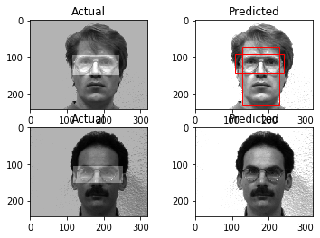

```python
# plot predictions for train dataset
plot_actual_vs_predicted(train_set, model, cfg)
```

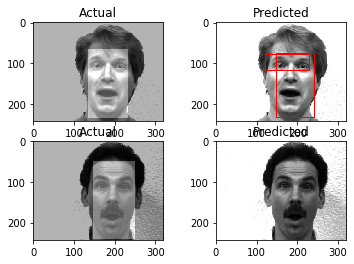

```python
# plot predictions for test dataset
plot_actual_vs_predicted(test_set, model, cfg)
```

# Conclusion and Future Work

Currently we have used 72 images to train and identify 8 different parameters, the accuracy of the results are not very high. The weights generated by using an external library from Matterport has not been giving us a more accurate results and flexibility to change the parameters, hence in the next project I am working on developing my own library.

For the Future work I will be working on comparing the accuracy using a YOLO architecture to compare the accuracy and the results.